# Adult Incomes

Sultan Alkadhi

2022-06-22

This dataset was compiled by the US Census Bureau in 1994. It is used to group individuals in the US to incomes above or below $50,000. Other variables in the dataset include age, gender, education, race, and hours-per-week worked, and others I feel were not worthy of including in this EDA.

# Data

Load libraries and dataset

```r
adult
```

```
## # A tibble: 48,842 × 15
##      age workclass fnlwgt education `educational-n…` `marital-status` occupation
##    <dbl> <chr>      <dbl> <chr>                <dbl> <chr>            <chr>
##  1    25 Private   226802 11th                     7 Never-married    Machine-o…
##  2    38 Private    89814 HS-grad                  9 Married-civ-spo… Farming-f…
##  3    28 Local-gov 336951 Assoc-ac…               12 Married-civ-spo… Protectiv…
##  4    44 Private   160323 Some-col…               10 Married-civ-spo… Machine-o…
##  5    18 ?         103497 Some-col…               10 Never-married    ?
##  6    34 Private   198693 10th                     6 Never-married    Other-ser…
##  7    29 ?         227026 HS-grad                  9 Never-married    ?
##  8    63 Self-emp… 104626 Prof-sch…               15 Married-civ-spo… Prof-spec…
##  9    24 Private   369667 Some-col…               10 Never-married    Other-ser…
## 10    55 Private   104996 7th-8th                  4 Married-civ-spo… Craft-rep…
## # … with 48,832 more rows, and 8 more variables: relationship <chr>,
## #   race <chr>, gender <chr>, `capital-gain` <dbl>, `capital-loss` <dbl>,
## #   `hours-per-week` <dbl>, `native-country` <chr>, income <chr>
```

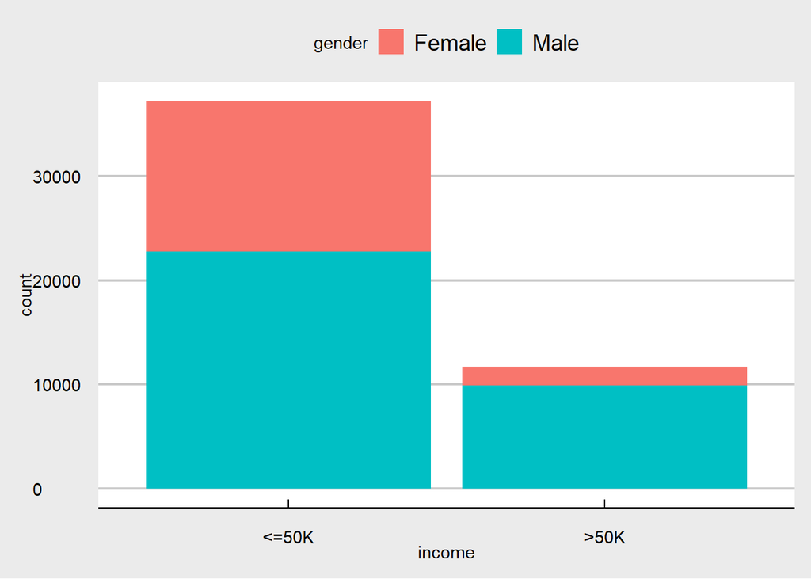

```r
ggplot(adult) +
 aes(x = income,fill=gender) +
 geom_bar(pstat="count") +
 theme_economist_white()
```

There are approx 50k entries in the dataset. Incomes above 50 are expectedly less represented. Interestingly, there are proportionally more females in the lower income category.

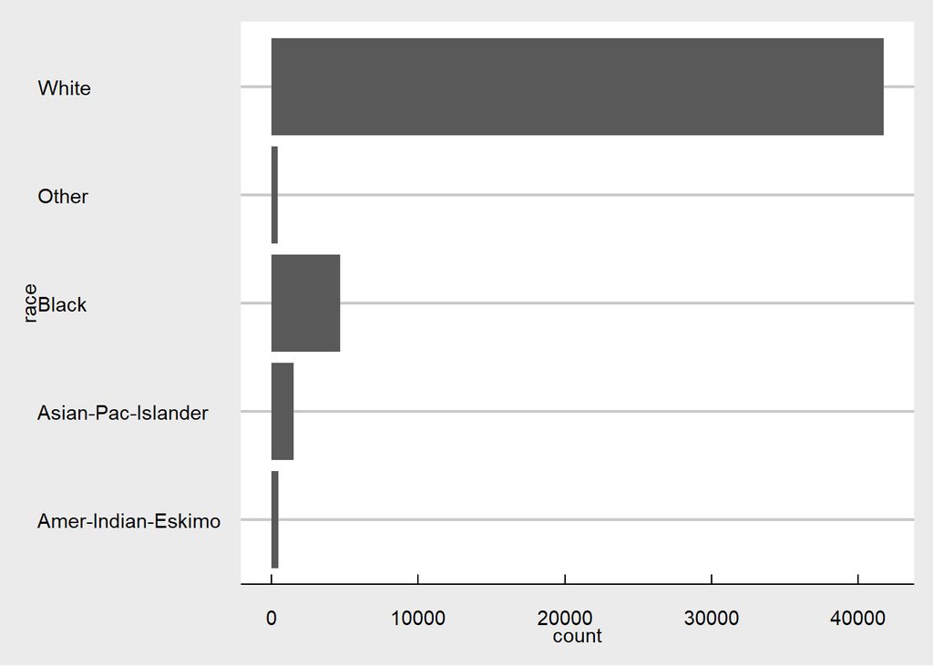

```r
ggplot(adult) +
  aes(x = race) +
  geom_bar() +
  coord_flip()+
  theme_economist_white()
```

Most of the dataset is of the white “race,” so further analysis of this column is not warranted.

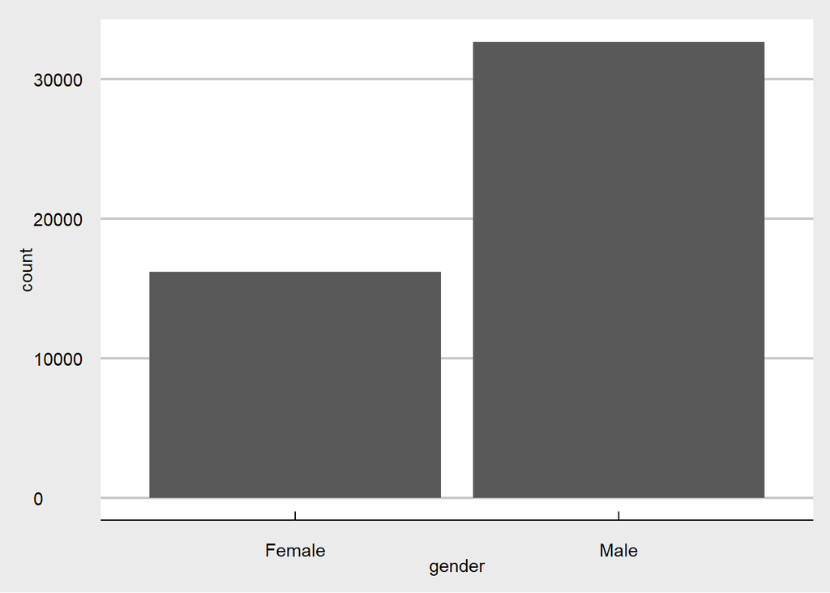

```r
ggplot(adult) +
  aes(x = gender) +
  geom_bar() +
  theme_economist_white()
```

```r
table(adult['gender'])
```

```
## gender
## Female   Male
##  16192  32650
```

Males are twice the number of females in this dataset for some reason.

# EDA

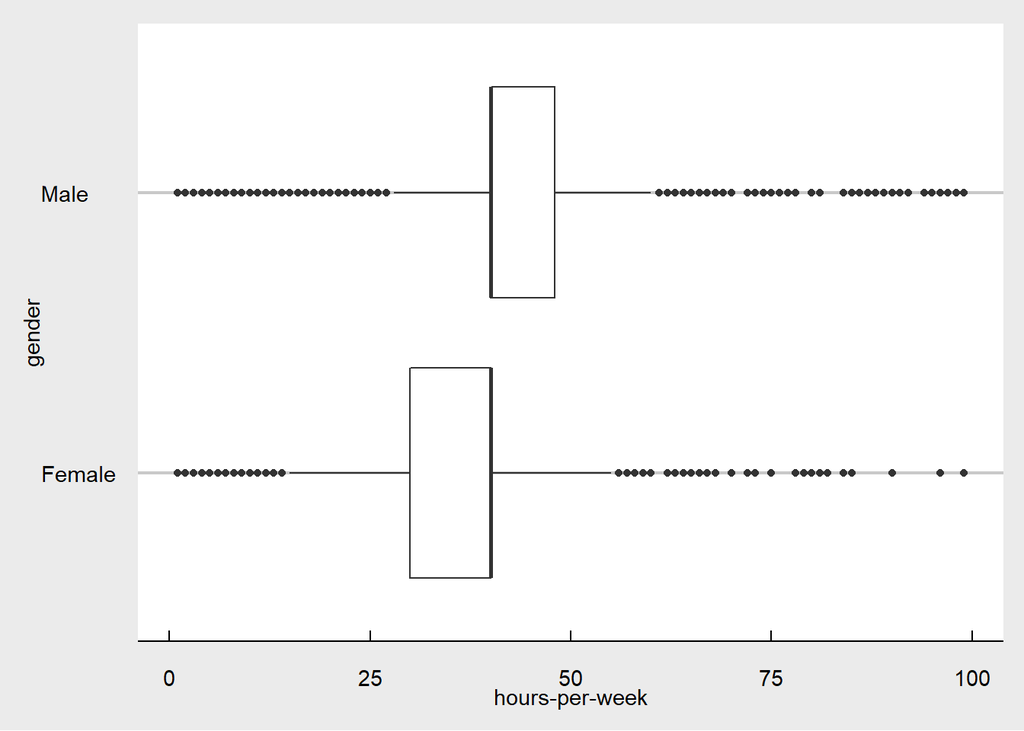

```r
ggplot(adult) +
 aes(x = `hours-per-week`, y = gender) +
 geom_boxplot() +
  theme_economist_white()
```

Men work longer hours than women, could be a reason for the income discrepancy.

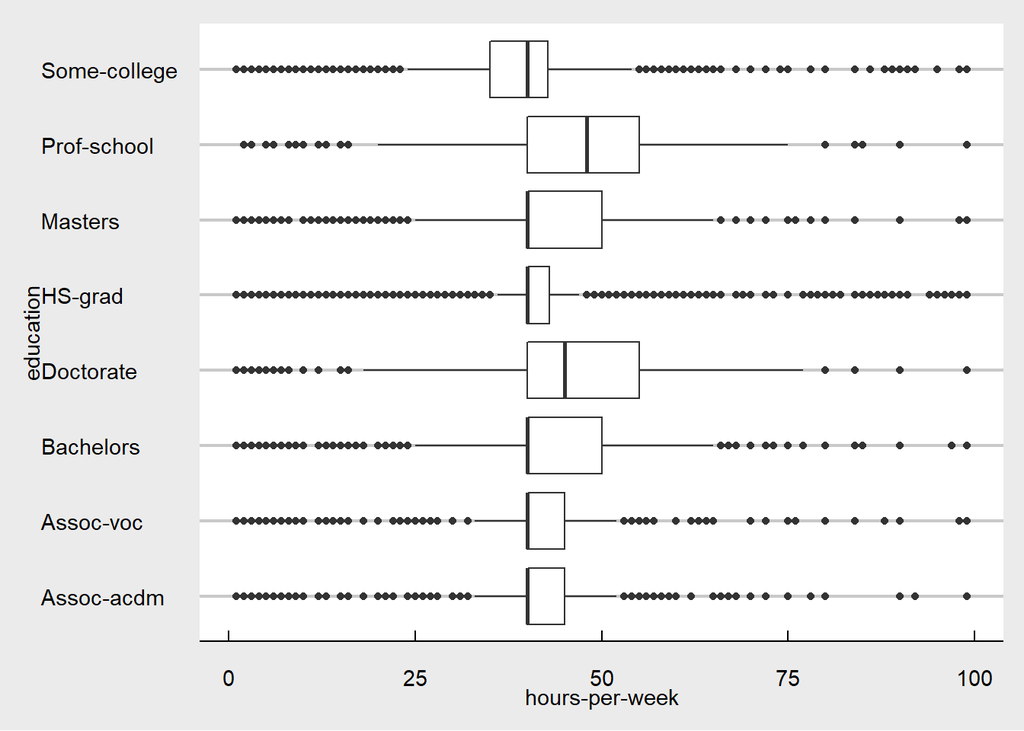

```r
adult %>%
 filter(!(education %in% c("12th", "1st-4th", "5th-6th", "9th", "Preschool", "11th", "10th", "7th-8th"))) %>%
ggplot(
 aes(x = `hours-per-week`, y = education)) +
 geom_boxplot() +
  theme_economist_white()
```

High school grad and ‘some college’ work the least amount of hours, while professional school and doctorates work the longest.

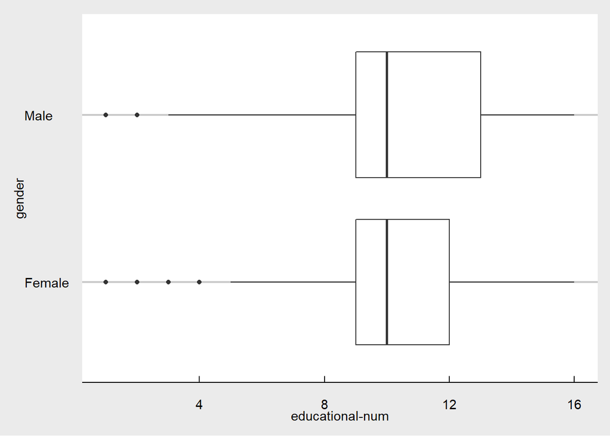

```r
ggplot(adult) +
 aes(x = `educational-num`, y = gender) +
 geom_boxplot() +
 theme_economist_white()
```

Men and women have comparable levels of education. So they should, in theory, receive the same incomes.

# Conclusion

Although the inequality in incomes between men and women is disturbing, an equal number of females was not included in this dataset. That being said, the discrepancy in incomes between them maybe in part explained by the longer hours worked by the former.

$~$